# 606 HW Week 1

Kyle Gilde

February 2, 2017

## 606 HW Week 1

Practice: 1.7 (available in R using the data(iris) command), 1.9, 1.23, 1.33, 1.55, 1.69

Graded: 1.8, 1.10, 1.28, 1.36, 1.48, 1.50, 1.56, 1.70

For 1.48, the following R code will create a vector scores that can be used to answer the question:

scores <- c(57, 66, 69, 71, 72, 73, 74, 77, 78, 78, 79, 79, 81, 81, 82, 83, 83, 88, 89, 94)

# 1.8 Smoking habits of UK residents.

1. What does each row of the data matrix represent? Observations aka cases
2. How many participants were included in the survey? 1691
3. Indicate whether each variable in the study is numerical or categorical. If numerical, identify as continuous or discrete. If categorical, indicate if the variable is ordinal.

sex: categorical, nominal age: numberical, discrete marital: categorical, nominal grossIncome: categorical, ordinal smoke: categorical, nominal amtWeekends: numerical, discrete — althouh technically you could smoke part of a cigarette, which would make it continuous amtWeekdays: numerical, discrete — althouh technically you could smoke part of a cigarette, which would make it continuous

# 1.10 Cheaters, scope of inference.

Exercise 1.5 introduces a study where researchers studying the relationship between honesty, age, and self-control conducted an experiment on 160 children between the ages of 5 and 15. The researchers asked each child to toss a fair coin in private and to record the outcome (white or black) on a paper sheet, and said they would only reward children who report white. Half the students were explicitly told not to cheat and the others were not given any explicit instructions. Diâµerences were observed in the cheating rates in the instruction and no instruction groups, as well as some diâµerences across childrenâs characteristics within each group.

1. Identify the population of interest and the sample in this study. ####population: all children between 5 and 15 ####sample: the 160 children between 5 and 15 in the experiment
2. Comment on whether or not the results of the study can be generalized to the population, and if the findings of the study can be used to establish causal relationships.

The question doesn’t specify whether the 160 children were randomly sampled or were volunteers. If they were randomly sampled, that would make the results generalizable to wthe population. Otherwise, the results would not be generalizable.

#### The question doesn’t explicitly state that the instruction/no-instruction treatment was randomly assigned. If it was randomly assigned, then a causal relationship could be established. Otherwise, only correlation can be established.

# 1.28 Reading the paper.

Below are excerpts from two articles published in the NY Times:

1. An article titled Risks: Smokers Found More Prone to Dementia states the following: Researchers analyzed data from 23,123 health plan members who participated in a voluntary exam and health behavior survey from 1978 to 1985, when they were 50-60 years old. 23 years later, about 25% of the group had dementia, including 1,136 with Alzheimer’s disease and 416 with vascular dementia. After adjusting for other factors, the researchers concluded that pack-aday smokers were 37% more likely than nonsmokers to develop dementia, and the risks went up with increased smoking; 44% for one to two packs a day; and twice the risk for more than two packs.

Based on this study, can we conclude that smoking causes dementia later in life? Explain your reasoning.

#### Since there was no random assignment of the # of cigarettes consumed in a day, we can’t conclude that there is a causal relationship between smoking & dementia – only that it’s correlation.

2. Another article titled The School Bully Is Sleepy states the following: The University of Michigan study, collected survey data from parents on each child’s sleep habits and asked both parents and teachers to assess behavioral concerns. About a third of the students studied were identified by parents or teachers as having problems with disruptive behavior or bullying. The researchers found that children who had behavioral issues and those who were identified as bullies were twice as likely to have shown symptoms of sleep disorders.

A friend of yours who read the article says, The study shows that sleep disorders lead to bullying in school children. Is this statement justified? If not, how best can you describe the conclusion that can be drawn from this study?

#### No, the most that can be concluded is that disruptive behavior/bullying & sleep disporders is correlated within the sample.

#### First, the article doesn’t state that the survey was conducted w/ a random sampling of students. Without knowing this, we don’t know if the results are generalizable to the popultation or only descriptive of the sample.

#### Secondly, the sleep treatment wasn’t randomly assigned to the sample, so the most that can be concluded is that the explanatory & response variable are correlated.

# 1.36 Exercise and mental health.

A researcher is interested in the effects of exercise on mental health and he proposes the following study: Use stratified random sampling to ensure representative proportions of 18-30, 31-40 and 41- 55 year olds from the population. Next, randomly assign half the subjects from each age group to exercise twice a week, and instruct the rest not to exercise. Conduct a mental health exam at the beginning and at the end of the study, and compare the results.

1. What type of study is this? randomized experiment
2. What are the treatment and control groups in this study? the twice-a-week exercisers & the group instructed not to exercise, respectively
3. Does this study make use of blocking? If so, what is the blocking variable? No
4. Does this study make use of blinding? The patients cannot be blinded. It doesn’t specify that the researchers were blinded.
5. Comment on whether or not the results of the study can be used to establish a causal relationship between exercise and mental health, and indicate whether or not the conclusions can be generalized to the population at large. Since there was both random sampling and assignment, the results can be used to establish a causal relationship & generalized to the popultion.
6. Suppose you are given the task of determining if this proposed study should get funding. Would you have any reservations about the study proposal? Yes, I would ask if it is necessary to blind the researchers.

# 1.48 Stats scores. Below are the final exam scores of twenty introductory statistics students.

57, 66, 69, 71, 72, 73, 74, 77, 78, 78, 79, 79, 81, 81, 82, 83, 83, 88, 89, 94 Create a box plot of the distribution of these scores. The five number summary provided below may be useful. Min Q1 Q2 (Median) Q3 Max 57 72.5 78.5 82.5 94

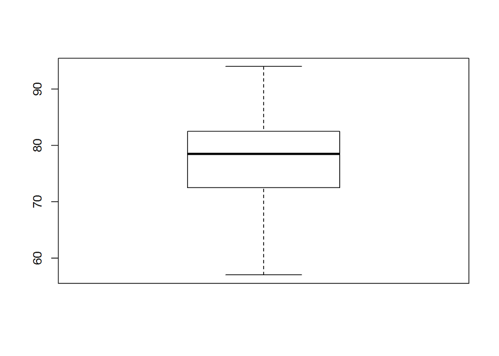

```r
scores <- c(57, 66, 69, 71, 72, 73, 74, 77, 78, 78, 79, 79, 81, 81, 82, 83, 83, 88, 89, 94)
boxplot(scores, range = 0)
```

# 1.56 Distributions and appropriate statistics, Part II .

- For each of the following, state whether you expect the distribution to be symmetric, right skewed, or left skewed.
- Also specify whether the mean or median would best represent a typical observation in the data,
- and whether the variability of observations would be best represented using the standard deviation or IQR. Explain your reasoning.
1. Housing prices in a country where 25% of the houses cost below $350,000, 50% of the houses cost below $450,000, 75% of the houses cost below $1,000,000 and there are a meaningful number of houses that cost more than $6,000,000.
- It will be right-skewed since there the 3rd quartile is less densely distributed than the first 2 quartiles and since there are a meaningful number of houses worth multiple times the value of the other houses.
- The median would best represent the typical observation since it will mitigate the effect of the extreme values.
- The variability would be best represented by the IQR because the SD would be sensitive to the extreme values.
2. Housing prices in a country where 25% of the houses cost below $300,000, 50% of the houses cost below $600,000, 75% of the houses cost below $900,000 and very few houses that cost more than $1,200,000.
- It will be a mostly symetrical distribution since the quartile ranges are very similar.
- The median would best represent the typical observation since it will mitigate the effect of the extreme values.
- The variability would be best represented by the IQR because the SD would be sensitive to the extreme values.
3. Number of alcoholic drinks consumed by college students in a given week. Assume that most of these students don’t drink since they are under 21 years old, and only a few drink excessively.
- It will be left-skewed distribution since most of the students will be at the minimum value of zero and since very few drink excessively.
- The median would best represent the typical observation since it will mitigate the effects of the all the non-drinkers and the excessive drinkers.
- The variability would be best represented by the IQR because the SD would be sensitive to all the non-drinkers and the excessive drinkers.
4. Annual salaries of the employees at a Fortune 500 company where only a few high level executives earn much higher salaries than all the other employees.
- It will be a mostly symetrical distribution.
- The median would best represent the typical observation since it will mitigate the effect of the extreme values of the high-level executives.
- The variability would be best represented by the IQR because the SD would be sensitive to the extreme values of the high-level executives.

# 1.70 Heart transplants.

The Stanford University Heart Transplant Study was conducted to determine whether an experimental heart transplant program increased lifespan. Each patient entering the program was designated an official heart transplant candidate, meaning that he was gravely ill and would most likely benefit from a new heart. Some patients got a transplant and some did not. The variable transplant indicates which group the patients were in; patients in the treatment group got a transplant and those in the control group did not. Another variable called survived was used to indicate whether or not the patient was alive at the end of the study. Of the 34 patients in the control group, 30 died. Of the 69 people in the treatment group, 45 died.

The transplant is at least marginally to moderately effective. While the transplant didn’t save the majority of the patients, it did save a much greater proportion than the placebo group.

3. What proportion of patients in the treatment group and what proportion of patients in the control group died?

```r
30/34
```

```
## [1] 0.8823529
```

```r
45/69
```

```
## [1] 0.6521739
```

```r
#  0.8823529
#  0.6521739


30/34 - 45/69
```

```
## [1] 0.230179
```

```r
# 0.230179
```

4. One approach for investigating whether or not the treatment is effective is to use a randomization technique.
1. What are the claims being tested? The experimental heart transplant program increased lifespan
2. The paragraph below describes the set up for such approach, if we were to do it without using statistical software. Fill in the blanks with a number or phrase, whichever is appropriate.

We write alive on **28** cards representing patients who were alive at the end of the study, and dead on **75** cards representing patients who were not Then, we shuâe these cards and split them into two groups: one group of size **69** representing treatment, and another group of size 34 representing control. We calculate the diâµerence between the proportion of dead cards in the treatment and control groups (treatment - control) and record this value. We repeat this 100 times to build a distribution centered at **0** Lastly, we calculate the fraction of simulations where the simulated diâµerences in proportions are **at least as extreme or greater.** If this fraction is low, we conclude that it is unlikely to have observed such an outcome by chance and that the null hypothesis should be rejected in favor of the alternative.